# P8106 Data Science II Final Project

# best group start here

### 1. data preparation.

#### 1. Read raw data

```r
# read in raw data
# drug_data = read.csv("../data/State_Drug_Utilization_Data_2015.csv")
# drug_name = read_xlsx("../data/anxiety drug names.xlsx")
# sunshine = read_xlsx("../data/sunshine duration by state.xlsx")
# acs2015 = read.csv("../data/acs2015_county_data.csv")
# happy_rank = c(28, 2, 9, 44, 10, 4, 18, 27, 12, 41, 1, 36, 35, 46, 14, 25, 49, 42, 22, 34, 30, 39, 7, 43, 45, 3, 20, 38, 21, 32, 16, 40, 23, 15, 47, 48, 31, 33, 26, 19, 6, 37, 11, 8, 29, 17, 24, 50, 13, 5)
# happy = data.frame(cbind(state.name, happy_rank)) %>%
#   mutate(State = state.name) %>%
#   select(-state.name)
# physician=read_xlsx("../data/physician.xlsx")
# save(drug_data,drug_name,sunshine,acs2015,happy,physician, file="raw_data.Rdata")
```

#### 2. Summarize acs2015 data by state, and save it as “acs_summary_by_state.Rdata”.

```r
# #acs data summary by state
# acs2015_summary = acs2015 %>%
#   group_by(State) %>%
#   summarize(population = sum(TotalPop, na.rm = TRUE),
#             men = sum(Men, na.rm = TRUE)/population,
#             women = sum(Women, na.rm = TRUE)/population,
#             hispanic = sum(0.01*Hispanic * TotalPop, na.rm = TRUE)/population,
#             white = sum(0.01*White * TotalPop, na.rm = TRUE)/population,
#             black = sum(0.01*Black * TotalPop, na.rm = TRUE)/population,
#             asian = sum(0.01*Asian * TotalPop, na.rm = TRUE)/population,
#             native = sum(0.01*Native * TotalPop, na.rm = TRUE)/population,
#             pacific = sum(0.01*Pacific * TotalPop, na.rm = TRUE)/population,
#             citizen = sum(Citizen, na.rm = TRUE)/population,
#             ave_income = sum(Income * TotalPop, na.rm = TRUE)/population,
#             income_per_cap = sum(as.numeric(IncomePerCap) * TotalPop, na.rm = TRUE)/population,
#             ave_Poverty = sum(Poverty * TotalPop, na.rm = TRUE)/population,
#             ave_ChildPoverty = sum(ChildPoverty * TotalPop, na.rm = TRUE)/population,
#             ave_Professional = sum(Professional * TotalPop, na.rm = TRUE)/population,
#             ave_Service = sum(Service * TotalPop, na.rm = TRUE)/population,
#             ave_Office = sum(Office * TotalPop, na.rm = TRUE)/population,
#             ave_Construction = sum(Construction * TotalPop, na.rm = TRUE)/population,
#             ave_Production = sum(Production * TotalPop, na.rm = TRUE)/population,
#             ave_Drive = sum(Drive * TotalPop, na.rm = TRUE)/population,
#             ave_Carpool = sum(Carpool * TotalPop, na.rm = TRUE)/population,
#             ave_Transit = sum(Transit * TotalPop, na.rm = TRUE)/population,
#             ave_Walk = sum(Walk * TotalPop, na.rm = TRUE)/population,
#             ave_WorkAtHome = sum(WorkAtHome * TotalPop, na.rm = TRUE)/population,
#             ave_MeanCommute = sum(MeanCommute * TotalPop, na.rm = TRUE)/population,
#             ave_SelfEmployed = sum(SelfEmployed * Employed, na.rm = TRUE)/sum(Employed),
#             ave_PublicWork = sum(PublicWork * Employed, na.rm = TRUE)/sum(Employed),
#             ave_PrivateWork = sum(PrivateWork * Employed, na.rm = TRUE)/sum(Employed),
#             ave_FamilyWork = sum(FamilyWork * Employed, na.rm = TRUE)/sum(Employed),
#             ave_Unemployment = sum(Unemployment * TotalPop, na.rm = TRUE)/population)
#
# save(acs2015_summary, file = "acs_summary_by_state.Rdata")
```

#### 3. Prepare the drug_name data: get all the names ready for “join” and save it as “drug name.Rdata”.

```r
# drug_name_1 = drug_name %>%
#   unnest_tokens(word, name) %>%
#   unique()
#
# data("stop_words")
# drug_name_2 = anti_join(drug_name_1, stop_words) %>%
#   mutate(word_upper = toupper(word), word_first_upper = toTitleCase(word)) %>%
#   gather(type, Product.Name, 1:3) %>%
#   select(Product.Name)
#
# save(drug_name_2, file = "drug name.Rdata")
```

#### 4. Select anti-anxiety drug by merging drug_data with “drug name.Rdata”(drug_name_2), and summarize by state. The result is “anxiety drug by state.Rdata”.

```r
# drug_data_anxiety_state = merge(drug_name_2, drug_data) %>%
#   mutate(Units.Reimbursed = as.numeric(Units.Reimbursed),
#          Number.of.Prescriptions = as.numeric(Number.of.Prescriptions),
#          Total.Amount.Reimbursed = as.numeric(Total.Amount.Reimbursed),
#          Medicaid.Amount.Reimbursed = as.numeric(Medicaid.Amount.Reimbursed),
#          State = abbr2state(State)) %>%
#   filter(Number.of.Prescriptions > 1, !is.na(State)) %>%
#   mutate(Product.Name = toupper(Product.Name)) %>%
#   group_by(State, Product.Name) %>%
#   summarise(Rx.Number = sum((Number.of.Prescriptions), na.rm=TRUE),
#             Reimburse.Unit = sum((Units.Reimbursed), na.rm=TRUE),
#             Reimburse.Amount.Tot = sum((Total.Amount.Reimbursed), na.rm=TRUE),
#             Reimburse.Amount.Medicaid = sum((Medicaid.Amount.Reimbursed), na.rm=TRUE))
#
# save(drug_data_anxiety_state, file = "anxiety drug by state.Rdata")
```

#### 5. Merge all data sets by state, and save as “data.Rdata”, which is our final data set for now.

```r
# geo_center = data.frame(cbind(state.name, state.center$x, state.center$y))
# colnames(geo_center)<-(c("State", "longitude", "latitude"))
#
# data = Reduce(function(x, y) merge(x, y, all=TRUE), list(acs2015_summary, drug_data_anxiety_state, happy, physician, sunshine, geo_center))
#
# data_final = data %>%
#   group_by(State) %>%
#   mutate(sum_reimburse = sum(Reimburse.Amount.Tot), reimburse_per_cap = sum_reimburse/population) %>%
#   select(-Product.Name, -Rx.Number, -Reimburse.Unit, -Reimburse.Amount.Tot, -Reimburse.Amount.Medicaid) %>%
#   distinct() %>%
#   na.omit()
#
# save(data_final, file = "data.Rdata")
```

We probably will use “Rx number”, “Reimburse.Amount.Tot”, or “Reimburse.Amount.Medicaid” as the reponse, and the other variables as the predictors.

### 3. Unsupervised learning.

#### 1. heirachical clustering

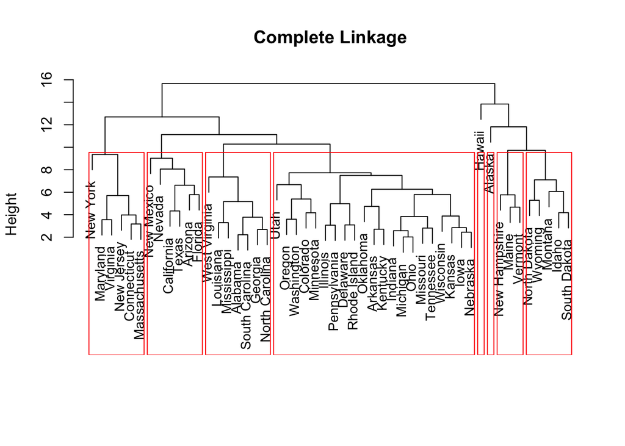

```r
load("data.Rdata")

data_cluster = data_final %>%
  ungroup() %>%
  clean_names() %>%
  select(-state, -place, -percent_sun, -total_hours, -population, -sum_reimburse, -longitude, -latitude)

data_cluster <- data.frame(lapply(data_cluster, function(x) as.numeric(x)))

data_cluster = scale(data_cluster)

row.names(data_cluster) = state.name

hc.complete <- hclust(dist(data_cluster), method = "complete")
plot(hc.complete,main = "Complete Linkage", xlab = "", sub = "", cex = .9)
rect.hclust(hc.complete, h = 9.5)
```

#### 2. PCA analysis

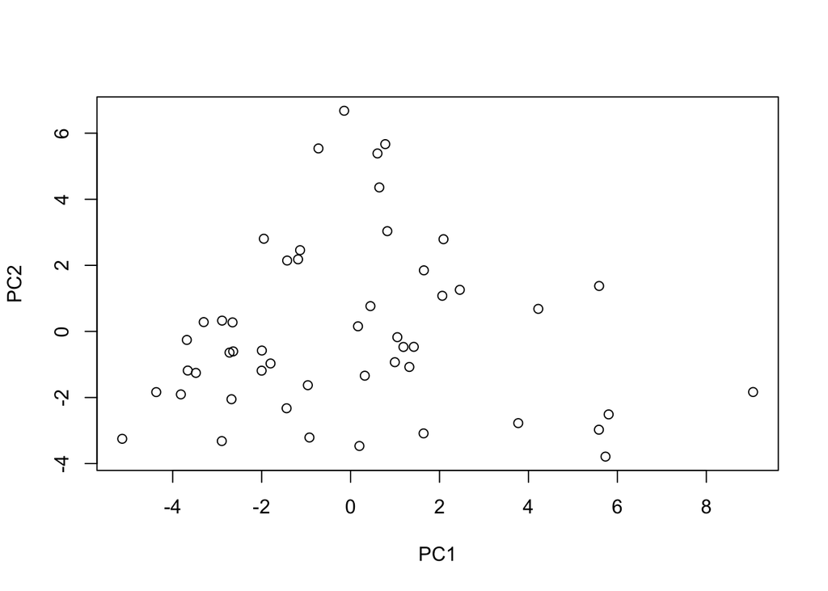

```r
data_pca = data_final %>%
  ungroup() %>%
  clean_names() %>%
  select(-state, -place, -percent_sun, -total_hours, -population, -sum_reimburse)

data_pca <- data.frame(lapply(data_pca, function(x) as.numeric(as.character(x))))

pr.out <- prcomp(data_pca, scale = TRUE)
plot(pr.out$"x"[,1],pr.out$"x"[,2],xlab="PC1",ylab="PC2")
```

#### 3. Descriptive Analysis

[figure not shown]

```r
library(ggplot2)
library(GGally)
data_final_pairwise <- select(data_final, starts_with("ave"))
ggpairs(data_final_pairwise[,2:20])
```

### 4. Supervised learning.

1. Split data into train and test datasets.

```r
data_regression = data_final %>%
  ungroup() %>%
  clean_names() %>%
  select(-state, -place, -percent_sun, -total_hours, -population, -sum_reimburse)

data_regression <- data.frame(lapply(data_regression, function(x) as.numeric(as.character(x))))

row.names(data_cluster) = state.name

set.seed(2018)
train_row = sample(1:50, 30)
train = data_regression[train_row, ]
test = data_regression[-train_row, ]
```

2. Linear regression

```r
linear <- lm(reimburse_per_cap ~., data = train)
summary(linear)
```

```
##
## Call:
## lm(formula = reimburse_per_cap ~ ., data = train)
##
## Residuals:
## ALL 30 residuals are 0: no residual degrees of freedom!
##
## Coefficients: (5 not defined because of singularities)
##                                    Estimate Std. Error t value Pr(>|t|)
## (Intercept)                      -3.018e+06         NA      NA       NA
## men                               2.078e+05         NA      NA       NA
## women                                    NA         NA      NA       NA
## hispanic                         -5.437e+04         NA      NA       NA
## white                            -4.679e+04         NA      NA       NA
## black                            -3.728e+04         NA      NA       NA
## asian                            -2.622e+04         NA      NA       NA
## native                           -7.173e+04         NA      NA       NA
## pacific                          -4.107e+05         NA      NA       NA
## citizen                          -1.427e+04         NA      NA       NA
## ave_income                       -3.198e-01         NA      NA       NA
## income_per_cap                    7.285e-01         NA      NA       NA
## ave_poverty                      -1.707e+02         NA      NA       NA
## ave_child_poverty                 1.316e+02         NA      NA       NA
## ave_professional                  2.793e+04         NA      NA       NA
## ave_service                       2.864e+04         NA      NA       NA
## ave_office                        2.843e+04         NA      NA       NA
## ave_construction                  2.783e+04         NA      NA       NA
## ave_production                    2.823e+04         NA      NA       NA
## ave_drive                         4.527e+02         NA      NA       NA
## ave_carpool                       4.767e+02         NA      NA       NA
## ave_transit                       5.120e+02         NA      NA       NA
## ave_walk                          1.047e+03         NA      NA       NA
## ave_work_at_home                  6.353e+02         NA      NA       NA
## ave_mean_commute                  2.647e+01         NA      NA       NA
## ave_self_employed                 1.239e+03         NA      NA       NA
## ave_public_work                   1.121e+03         NA      NA       NA
## ave_private_work                  9.824e+02         NA      NA       NA
## ave_family_work                  -1.977e+03         NA      NA       NA
## ave_unemployment                 -2.676e+02         NA      NA       NA
## happy_rank                        2.229e+01         NA      NA       NA
## physician_per_100_000_population         NA         NA      NA       NA
## clear_days                               NA         NA      NA       NA
## longitude                                NA         NA      NA       NA
## latitude                                 NA         NA      NA       NA
##
## Residual standard error: NaN on 0 degrees of freedom
## Multiple R-squared:      1,  Adjusted R-squared:    NaN
## F-statistic:   NaN on 29 and 0 DF,  p-value: NA
```

```r
library(olsrr)
ols_step_forward_p(linear)
```

```
## Forward Selection Method
## ---------------------------
##
## Candidate Terms:
##
## 1. men
## 2. women
## 3. hispanic
## 4. white
## 5. black
## 6. asian
## 7. native
## 8. pacific
## 9. citizen
## 10. ave_income
## 11. income_per_cap
## 12. ave_poverty
## 13. ave_child_poverty
## 14. ave_professional
## 15. ave_service
## 16. ave_office
## 17. ave_construction
## 18. ave_production
## 19. ave_drive
## 20. ave_carpool
## 21. ave_transit
## 22. ave_walk
## 23. ave_work_at_home
## 24. ave_mean_commute
## 25. ave_self_employed
## 26. ave_public_work
## 27. ave_private_work
## 28. ave_family_work
## 29. ave_unemployment
## 30. happy_rank
## 31. physician_per_100_000_population
## 32. clear_days
## 33. longitude
## 34. latitude
##
## We are selecting variables based on p value...
##
## Variables Entered:
```

```
## - physician_per_100_000_population
```

```
## - citizen
```

```
## - ave_private_work
```

```
## - ave_service
```

```
## - ave_family_work
```

```
## - ave_mean_commute
```

```
## - longitude
```

```
## - clear_days
```

```
## - ave_construction
```

```
## - ave_production
```

```
## - income_per_cap
```

```
## - ave_walk
```

```
## - ave_drive
```

```
## - ave_carpool
##
## No more variables to be added.
##
## Final Model Output
## ------------------
##
##                           Model Summary
## -----------------------------------------------------------------
## R                       0.941       RMSE                 133.662
## R-Squared               0.885       Coef. Var             31.566
## Adj. R-Squared          0.778       MSE                17865.446
## Pred R-Squared          0.673       MAE                   64.880
## -----------------------------------------------------------------
##  RMSE: Root Mean Square Error
##  MSE: Mean Square Error
##  MAE: Mean Absolute Error
##
##                                 ANOVA
## ----------------------------------------------------------------------
##                    Sum of
##                   Squares        DF    Mean Square      F        Sig.
## ----------------------------------------------------------------------
## Regression    2064076.332        14     147434.024    8.252     1e-04
## Residual       267981.689        15      17865.446
## Total         2332058.020        29
## ----------------------------------------------------------------------
##
##                                                  Parameter Estimates
## ----------------------------------------------------------------------------------------------------------------------
##                            model         Beta    Std. Error    Std. Beta      t        Sig         lower        upper
## ----------------------------------------------------------------------------------------------------------------------
##                      (Intercept)     3059.902      4406.685                  0.694    0.498    -6332.725    12452.528
## physician_per_100_000_population        1.004         0.685        0.274     1.465    0.164       -0.457        2.464
##                          citizen    -3652.065      1839.272       -0.430    -1.986    0.066    -7572.380      268.249
##                 ave_private_work       -2.199        16.672       -0.029    -0.132    0.897      -37.733       33.336
##                      ave_service        2.411        49.821        0.008     0.048    0.962     -103.780      108.603
##                  ave_family_work    -1723.542       615.324       -0.418    -2.801    0.013    -3035.074     -412.010
##                 ave_mean_commute        0.096        24.026        0.001     0.004    0.997      -51.115       51.306
##                        longitude        1.923         4.902        0.111     0.392    0.700       -8.525       12.372
##                       clear_days       -3.472         1.771       -0.358    -1.961    0.069       -7.246        0.303
##                 ave_construction       73.850        33.147        0.498     2.228    0.042        3.198      144.501
##                   ave_production      -92.480        28.060       -0.853    -3.296    0.005     -152.289      -32.672
##                   income_per_cap       -0.060         0.027       -0.796    -2.237    0.041       -0.117       -0.003
##                         ave_walk      178.567        74.419        0.891     2.399    0.030       19.947      337.188
##                        ave_drive       43.210        28.397        0.651     1.522    0.149      -17.316      103.736
##                      ave_carpool     -125.224        86.967       -0.428    -1.440    0.170     -310.591       60.142
## ----------------------------------------------------------------------------------------------------------------------
```

```
##
##                                        Selection Summary
## ------------------------------------------------------------------------------------------------
##         Variable                                          Adj.
## Step                Entered                 R-Square    R-Square    C(p)      AIC         RMSE
## ------------------------------------------------------------------------------------------------
##    1    physician_per_100_000_population      0.3926      0.3709     NaN    414.0114    224.9208
##    2    citizen                               0.5280      0.4931     NaN    408.4430    201.9039
##    3    ave_private_work                      0.5934      0.5465     NaN    405.9703    190.9701
##    4    ave_service                           0.6308      0.5717     NaN    405.0773    185.5845
##    5    ave_family_work                       0.6494      0.5763     NaN    405.5281    184.5835
##    6    ave_mean_commute                      0.6834      0.6008     NaN    404.4636    179.1648
##    7    longitude                             0.7026      0.6079     NaN    404.5917    177.5644
##    8    clear_days                            0.7443      0.6469     NaN    402.0590    168.5190
##    9    ave_construction                      0.7698      0.6662     NaN    400.9045    163.8364
##   10    ave_production                        0.8108      0.7112     NaN    397.0221    152.3949
##   11    income_per_cap                        0.8341      0.7328     NaN    395.0726    146.5965
##   12    ave_walk                              0.8466      0.7383     NaN    394.7313    145.0736
##   13    ave_drive                             0.8692      0.7629     NaN    391.9446    138.0721
##   14    ave_carpool                           0.8851      0.7778     NaN    390.0606    133.6617
## ------------------------------------------------------------------------------------------------
```

```r
linear_new <- lm(reimburse_per_cap ~ physician_per_100_000_population + citizen + ave_private_work + ave_service + ave_family_work + ave_mean_commute + longitude + clear_days + ave_construction + ave_production + income_per_cap + ave_walk + ave_drive + ave_carpool, data = train)
summary(linear_new)
```

```
##
## Call:
## lm(formula = reimburse_per_cap ~ physician_per_100_000_population +
##     citizen + ave_private_work + ave_service + ave_family_work +
##     ave_mean_commute + longitude + clear_days + ave_construction +
##     ave_production + income_per_cap + ave_walk + ave_drive +
##     ave_carpool, data = train)
##
## Residuals:
##      Min       1Q   Median       3Q      Max
## -225.154  -33.381   -5.094   28.071  262.962
##
## Coefficients:
##                                    Estimate Std. Error t value Pr(>|t|)
## (Intercept)                       3.060e+03  4.407e+03   0.694   0.4981
## physician_per_100_000_population  1.004e+00  6.852e-01   1.465   0.1636
## citizen                          -3.652e+03  1.839e+03  -1.986   0.0657 .
## ave_private_work                 -2.199e+00  1.667e+01  -0.132   0.8968
## ave_service                       2.411e+00  4.982e+01   0.048   0.9620
## ave_family_work                  -1.724e+03  6.153e+02  -2.801   0.0134 *
## ave_mean_commute                  9.560e-02  2.403e+01   0.004   0.9969
## longitude                         1.923e+00  4.902e+00   0.392   0.7003
## clear_days                       -3.472e+00  1.771e+00  -1.961   0.0688 .
## ave_construction                  7.385e+01  3.315e+01   2.228   0.0416 *
## ave_production                   -9.248e+01  2.806e+01  -3.296   0.0049 **
## income_per_cap                   -5.972e-02  2.669e-02  -2.237   0.0409 *
## ave_walk                          1.786e+02  7.442e+01   2.399   0.0299 *
## ave_drive                         4.321e+01  2.840e+01   1.522   0.1489
## ave_carpool                      -1.252e+02  8.697e+01  -1.440   0.1704
## ---
## Signif. codes:  0 '***' 0.001 '**' 0.01 '*' 0.05 '.' 0.1 ' ' 1
##
## Residual standard error: 133.7 on 15 degrees of freedom
## Multiple R-squared:  0.8851, Adjusted R-squared:  0.7778
## F-statistic: 8.252 on 14 and 15 DF,  p-value: 0.0001082
```

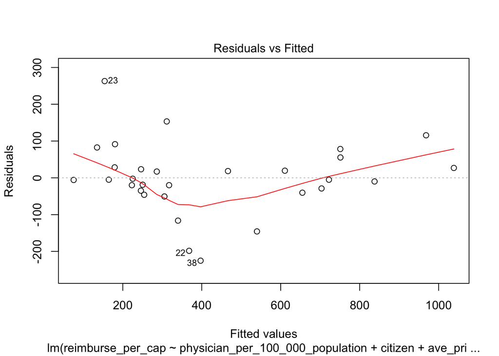

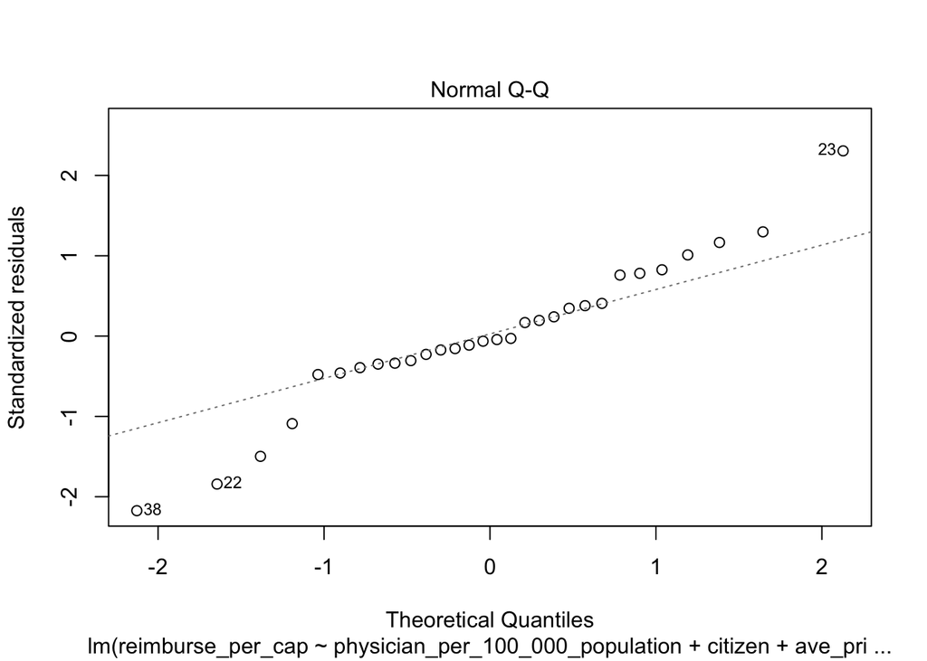

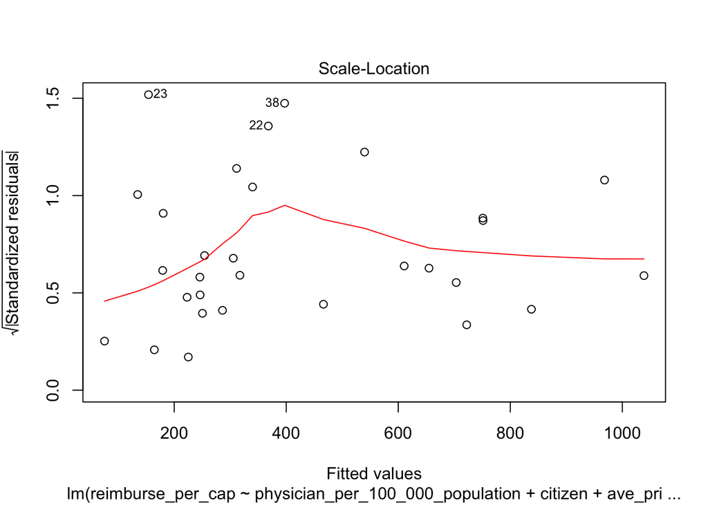

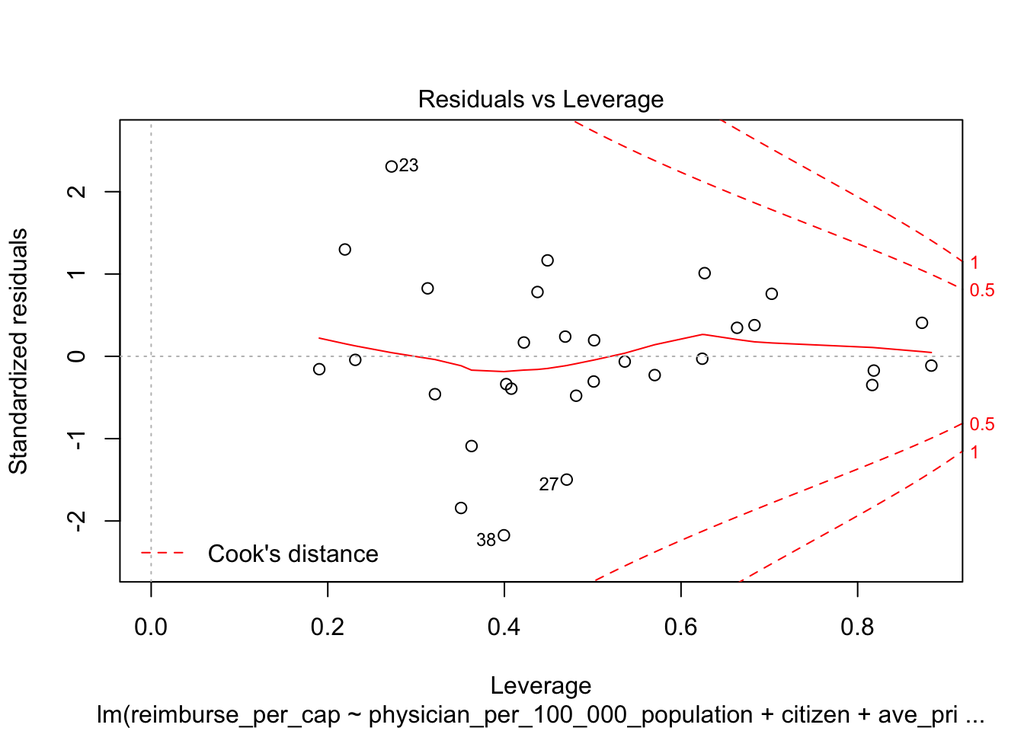

```r
plot(linear_new)
```